# Trace amine-associated receptor 1 (TAAR1) agonists for psychosis - Results from the human studies

### 6.2.16 Hypotension

#### Timepoint 1: *1 day - 2 weeks*

No usable data available from RCT.

#### Timepoint 2: *3 weeks - 13 weeks*

No usable data available from RCT.

#### Timepoint 3: *> 13 weeks*

No usable data available from RCT.

### 2.6.18 Dizziness

#### Timepoint 1: *1 day - 2 weeks*

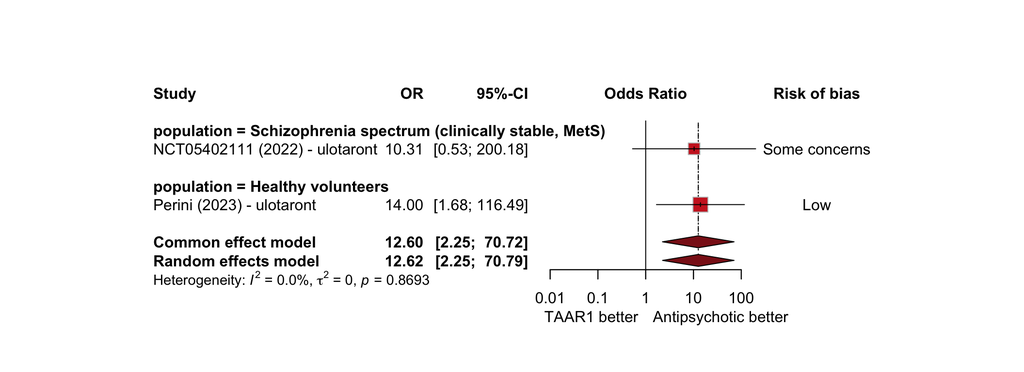

**Figure 59** Forest plot for dizziness for the comparison of TAAR1 agonist vs. antipsychotics at 1 day to 2 weeks. The comparison groups were previous antipsychotics (NCT05402111) or amisulpride (Perini et al 2023). The overall risk of bias of the studies for this outcome is presented. Studies with no estimable effect size had 0 events in both arms. OR: Odds ratio, MetS: Metabolic Syndrome, 95%CI: 95% confidence interval.

#### Timepoint 2: *3 weeks - 13 weeks*

No usable data available from RCT.

#### Timepoint 3: *> 13 weeks*

No usable data available from RCT.

### 6.2.18 Nausea or vomiting

Terms that were considered as reported in the trials: nausea, vomiting, emesis

#### Timepoint 1: *1 day - 2 weeks*

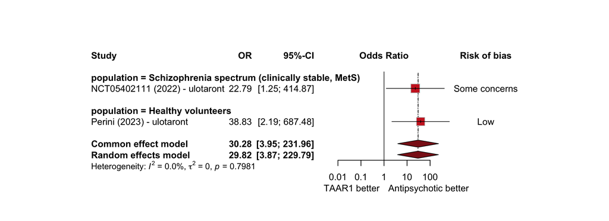

**Figure 60** Forest plot for nausea or vomitting for the comparison of TAAR1 agonist vs. antipsychotics at 1 day to 2 weeks.It should be noted that the studies (Perini et al. 2023) and Milanović et al. (2024) examined ulotaront that is also a partial agonist of 5-HT1A causing potentially gastrointestinal side-effects. In comparison, ralmitaront is not a partial agonist of the 5-HT1A receptor. The comparison groups were previous antipsychotics (NCT05402111) or amisulpride (Perini et al 2023). The overall risk of bias of the studies for this outcome is presented. OR: Odds ratio, MetS: Metabolic Syndrome, 95%CI: 95% confidence interval.

#### Timepoint 2: *3 weeks - 13 weeks*

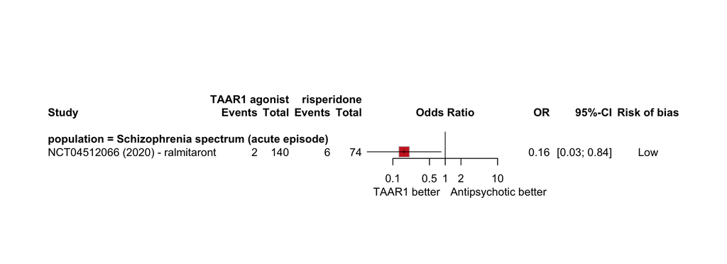

**Figure 61** Forest plot for nausea or vomitting for the comparison of TAAR1 agonist vs. antipsychotics at 3-13 weeks (primary timepoint). It should be noted that the study (Roche 2022) examined ralmitaront, which compared to ulotaront is not a partial agonist of the 5-HT1A receptor that can be associated with gastrointestinal side effects. The overall risk of bias of the studies for this outcome is presented. OR: Odds ratio, 95%CI: 95% confidence interval.

#### Timepoint 3: *> 13 weeks*

No usable data available from RCT.

### 6.2.19 QTc prolongation

#### Timepoint 1: *1 day - 2 weeks*

There were usable data for one study (Milanović et al. 2024), which reported 0 events in both groups so that an effect size could not be estimated with the current approach.

#### Timepoint 2: *3 weeks - 13 weeks*

No usable data available from RCT.

#### Timepoint 3: *> 13 weeks*

No usable data available from RCT.

### 6.2.20 QTc interval in msec

#### Timepoint 1: *1 day - 2 weeks*

No usable data available from RCT.

#### Timepoint 2: *3 weeks - 13 weeks*

No usable data available from RCT.

#### Timepoint 3: *> 13 weeks*

No usable data available from RCT.

### 6.2.21 Weight increased

#### Timepoint 1: *1 day - 2 weeks*

No usable data available from RCT.

#### Timepoint 2: *3 weeks - 13 weeks*

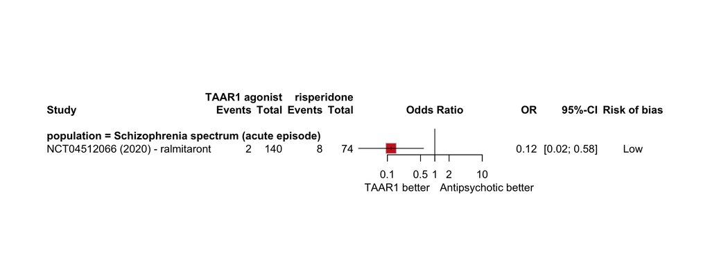

**Figure 62** Forest plot for weight increase for the comparison of TAAR1 agonist vs. antipsychotics at 3-13 weeks (primary timepoint). The overall risk of bias of the studies for this outcome is presented. OR: Odds ratio, 95%CI: 95% confidence interval.

#### Timepoint 3: *> 13 weeks*

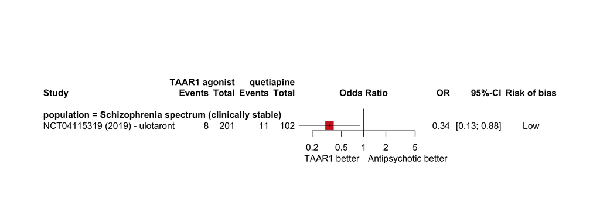

**Figure 63** Forest plot for weight increase for the comparison of TAAR1 agonist vs. antipsychotics at >13 weeks. The overall risk of bias of the studies for this outcome is presented. OR: Odds ratio, 95%CI: 95% confidence interval.

### 6.2.21 Weight in kg

#### Timepoint 1: *1 day - 2 weeks*

No usable data available from RCT.

#### Timepoint 2: *3 weeks - 13 weeks*

No usable data available from RCT.

#### Timepoint 3: *> 13 weeks*

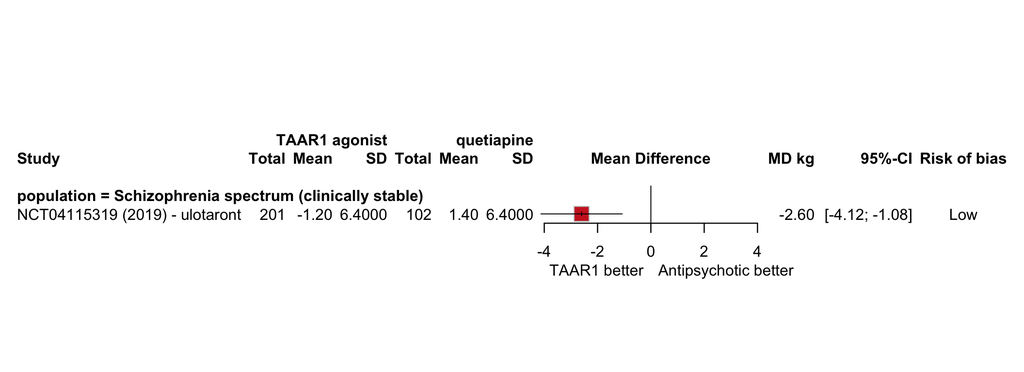

**Figure 60** Forest plot for weight change in kg for the comparison of TAAR1 agonist vs. antipsychotics at >13 weeks. The overall risk of bias of the studies for this outcome is presented. MD:Mean difference, SD: standard deviation, 95%CI: 95% confidence intervals.

### 6.2.23 Hyperprolactinemia

#### Timepoint 1: *1 day - 2 weeks*

No usable data available from RCT.

#### Timepoint 2: *3 weeks - 13 weeks*

No usable data available from RCT.

#### Timepoint 3: *> 13 weeks*

No usable data available from RCT.

### 6.2.24 Prolactin levels in ng/ml

#### Timepoint 1: *1 day - 2 weeks*

No usable data available from RCT.

#### Timepoint 2: *3 weeks - 13 weeks*

No usable data available from RCT.

#### Timepoint 3: *> 13 weeks*

No usable data available from RCT.

### 6.2.25 Akathisia

#### Timepoint 1: *1 day - 2 weeks*

No usable data available from RCT.

#### Timepoint 2: *3 weeks - 13 weeks*

No usable data available from RCT.

#### Timepoint 3: *> 13 weeks*

No usable data available from RCT.

### 6.2.26 Exrapyramidal symptoms

#### Timepoint 1: *1 day - 2 weeks*

No usable data available from RCT.

#### Timepoint 2: *3 weeks - 13 weeks*

No usable data available from RCT.

#### Timepoint 3: *> 13 weeks*

No usable data available from RCT.

### 6.2.27 Anxiety

#### Timepoint 1: *1 day - 2 weeks*

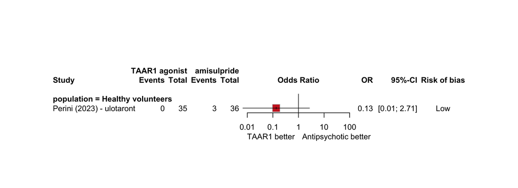

**Figure 66** Forest plot for anxiety as adverse event for the comparison of TAAR1 agonist vs. antipsychotics at 1 day to 2 weeks. The overall risk of bias of the studies for this outcome is presented. OR: Odds ratio, 95%CI: 95% confidence interval.

#### Timepoint 2: *3 weeks - 13 weeks*

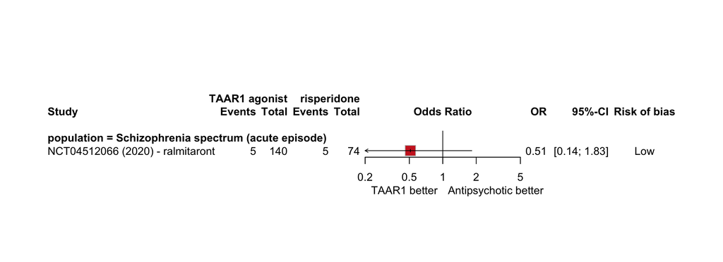

**Figure 67** Forest plot for anxiety as adverse event for the comparison of TAAR1 agonist vs. antipsychotics at 3-13 weeks (primary timepoint). The overall risk of bias of the studies for this outcome is presented. OR: Odds ratio, 95%CI: 95% confidence interval.

#### Timepoint 3: *> 13 weeks*

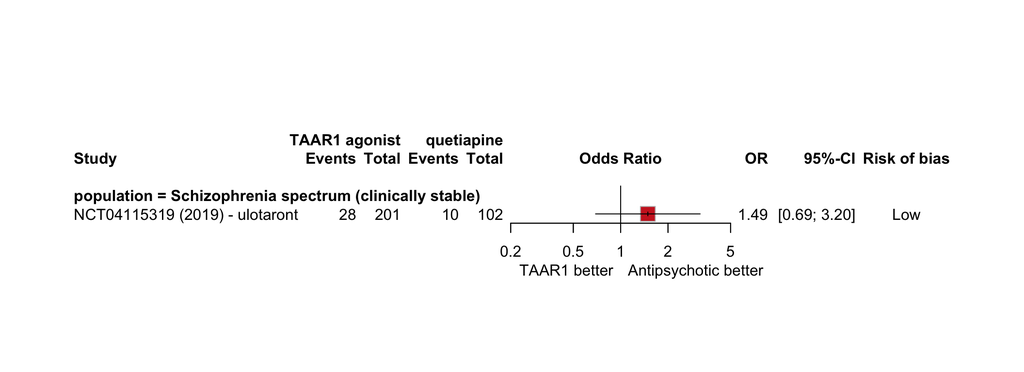

**Figure 68** Forest plot for anxiety as adverse event for the comparison of TAAR1 agonist vs. antipsychotics at >13 weeks. The overall risk of bias of the studies for this outcome is presented. OR: Odds ratio, 95%CI: 95% confidence interval.

### 6.2.28 Agitation

#### Timepoint 1: *1 day - 2 weeks*

No usable data available from RCT.

#### Timepoint 2: *3 weeks - 13 weeks*

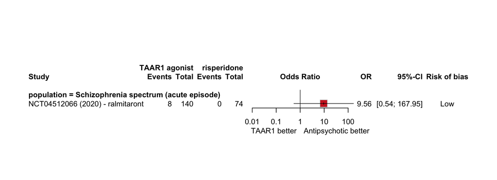

**Figure 69** Forest plot for agitation for the comparison of TAAR1 agonist vs. antipsychotics at 3-13 weeks (primary timepoint). The overall risk of bias of the studies for this outcome is presented. OR: Odds ratio, 95%CI: 95% confidence interval.

#### Timepoint 3: *> 13 weeks*

No usable data available from RCT.

### 6.2.29 Headache

#### Timepoint 1: *1 day - 2 weeks*

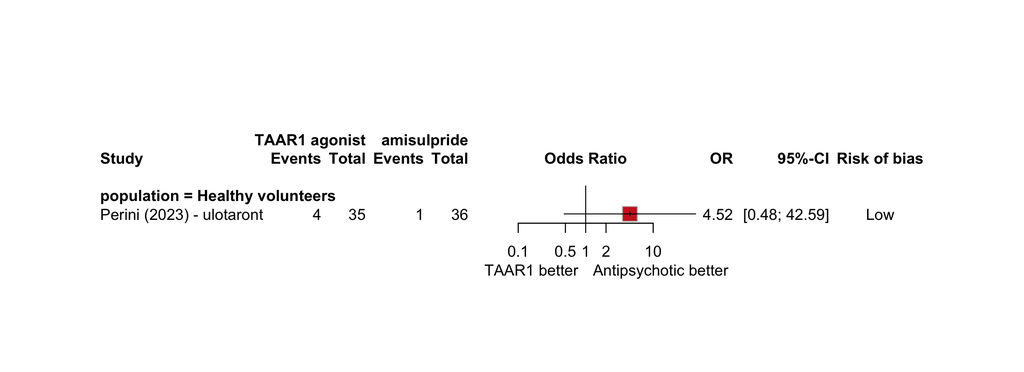

**Figure 70** Forest plot for headache as adverse event for the comparison of TAAR1 agonist vs. antipsychotics at 1 day to 2 weeks. The overall risk of bias of the studies for this outcome is presented. OR: Odds ratio, 95%CI: 95% confidence interval.

#### Timepoint 2: *3 weeks - 13 weeks*

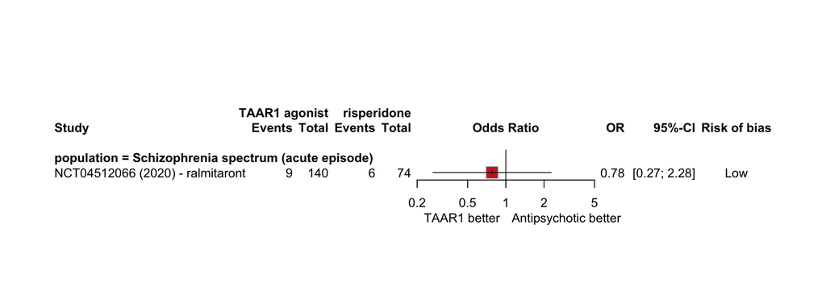

**Figure 71** Forest plot for headache for the comparison of TAAR1 agonist vs. antipsychotics at 3-13 weeks (primary timepoint). The overall risk of bias of the studies for this outcome is presented. OR: Odds ratio, 95%CI: 95% confidence interval.

#### Timepoint 3: *> 13 weeks*

No usable data available from RCT.

### 6.2.30 Sedation

#### Timepoint 1: *1 day - 2 weeks*

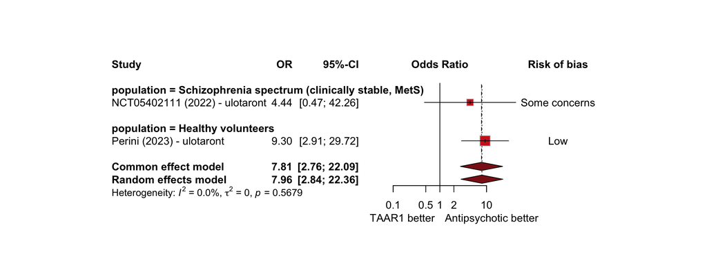

**Figure 72** Forest plot for sedation for the comparison of TAAR1 agonist vs. antipsychotics at 1 day to 2 weeks. The comparison groups were previous antipsychotics (NCT05402111) or amisulpride (Perini et al 2023). The overall risk of bias of the studies for this outcome is presented. OR: Odds ratio, MetS: Metabolic Syndrome, 95%CI: 95% confidence interval.

#### Timepoint 2: *3 weeks - 13 weeks*

No usable data available from RCT.

#### Timepoint 3: *> 13 weeks*

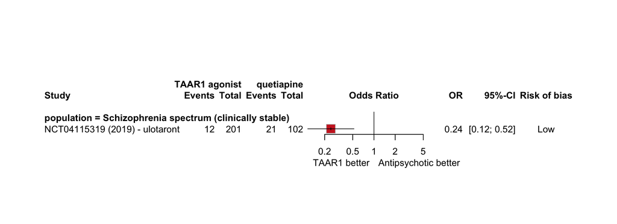

**Figure 73** Forest plot for sedation for the comparison of TAAR1 agonist vs. antipsychotics at >13 weeks. The overall risk of bias of the studies for this outcome is presented. OR: Odds ratio, 95%CI: 95% confidence interval.

### 6.2.31 Insomnia

#### Timepoint 1: *1 day - 2 weeks*

No usable data available from RCT.

#### Timepoint 2: *3 weeks - 13 weeks*

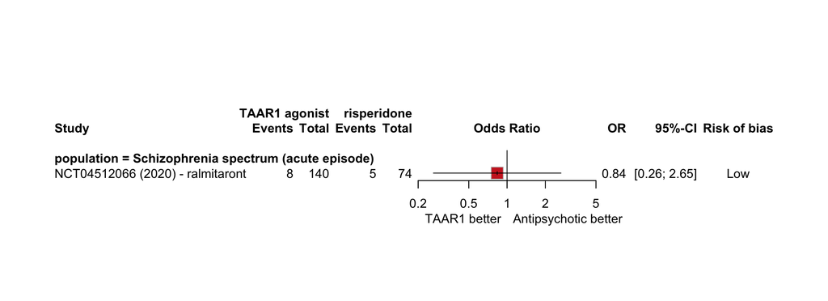

**Figure 74** Forest plot for insomnia for the comparison of TAAR1 agonist vs. antipsychotics at 3-13 weeks (primary timepoint). The overall risk of bias of the studies for this outcome is presented. OR: Odds ratio, 95%CI: 95% confidence interval.

#### Timepoint 3: *> 13 weeks*

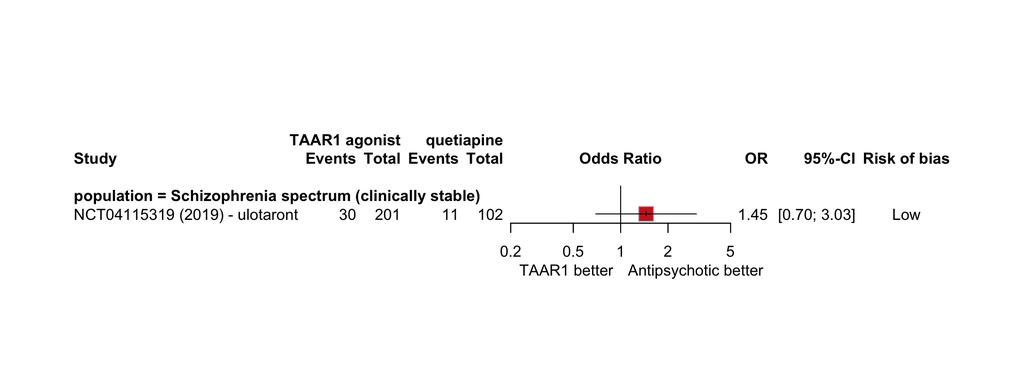

**Figure 75** Forest plot for insomnia for the comparison of TAAR1 agonist vs. antipsychotics at >13 weeks. The overall risk of bias of the studies for this outcome is presented. OR: Odds ratio, 95%CI: 95% confidence interval.

### 6.2.32 Summary outcome plots

#### Efficacy outcomes

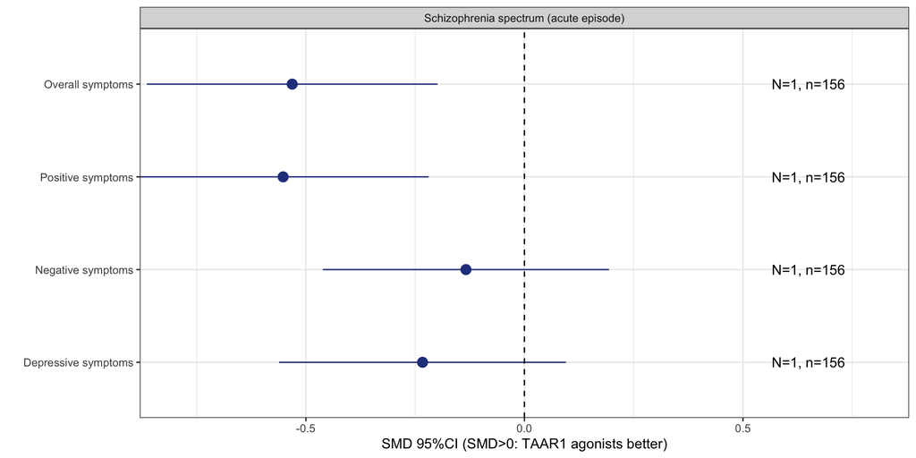

**Figure 76** Summary plot for efficacy outcomes at 4 weeks for the comparison of TAAR1 agonists versus antipscyhotcs in patients with an acute episode of schizophrenia. There were only data for the timepoint of 3-13 weeks. There were only data for ralmitaront as TAAR1 agonist and risperidone as control group. SMD>0 correspond to more symptom improvement by TAAR1 agonists compared to antipsychotic. SMD: Standardized mean difference, 95%CI: 95% confidence interval. N=number of studies, n=number of participants.

It should be noted that there were also data for relapse that are not displayed in this figure (see instead 2.6.9).

#### Dropouts and side-effects

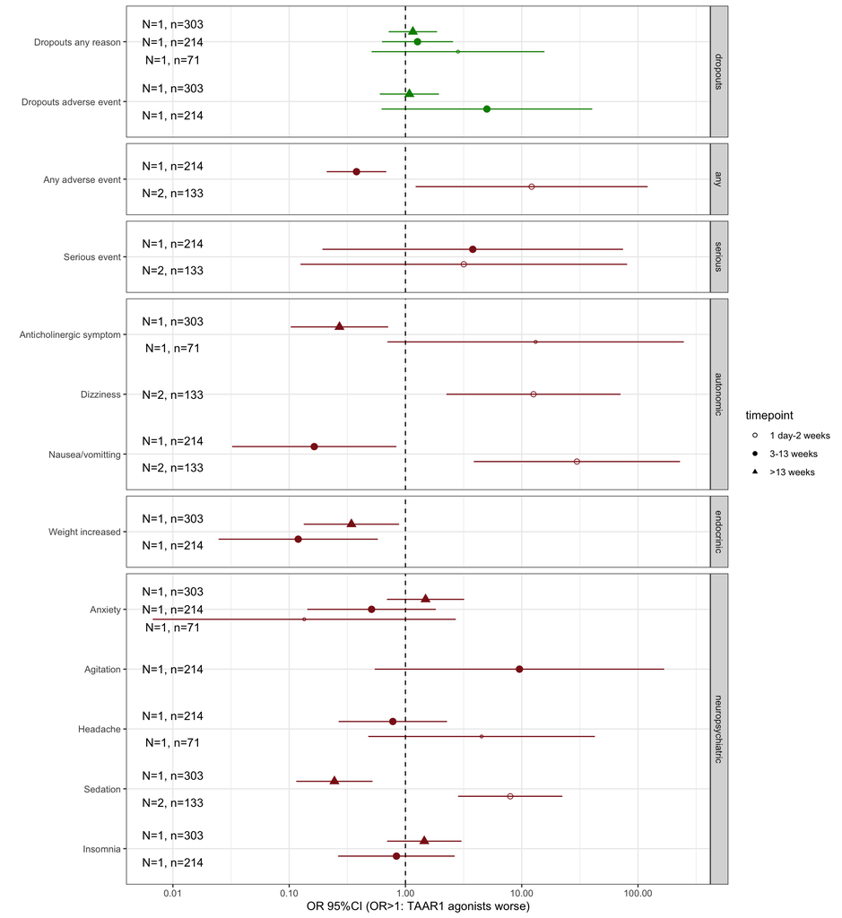

**Figure 77** Summary forest plot for dropouts and side-effects for the comparison of TAAR1 agonists compared to antipsychotics and for the three timepoints with usable data. There were data for single doses of ulotaront versus amisulpride in healthy volunteers at 1 day, single dose of ulotaront versus previous antipsychotic in adults with schizophrenia and concurrent metabolic syndrome at 1 day, ralmitaront versus risperidone in acute schizophrenia or schizoaffective disorder at 4 weeks, ulotaront versus quetiapine in clinically stable adults with schizophrenia at 52 weeks. The size of the points is proportional to the number of participants. OR>1 corresponds to more events with TAAR1 agonists compared to antipsychotics. OR: Odds ratio, 95%CI: 95% confidence interval. N=number of studies, n=number of participants.

## 6.3 *TAAR1 agonist vs placebo (adjunctive to antipsychotic treatment)*

### 6.3.1 Overall symptoms (primary outcome)

#### Timepoint 1: *1 day - 2 weeks*

No usable data available from RCT.

#### Timepoint 2: *3 weeks - 13 weeks*

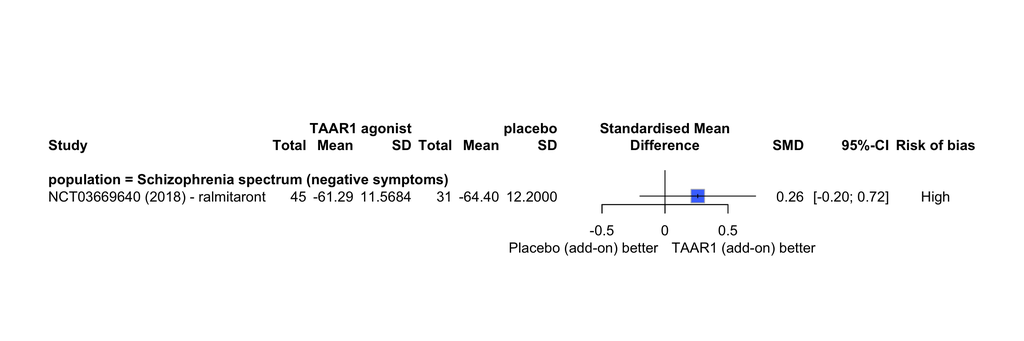

**Figure 78** Forest plot for overall symptoms (primary outcome, measured with PANSS total) for the comparison of adjunctive TAAR1 agonist vs. placebo to antipsychotic treatment at 3-13 weeks (primary timepoint). The overall risk of bias of the studies for this outcome is presented. SMD:Standardized mean difference, 95%CI: 95% confidence intervals, SD: Standard deviation.

#### Timepoint 3: *> 13 weeks*

No usable data available from RCT.

### 6.3.2 Positive symptoms

#### Timepoint 1: *1 day - 2 weeks*

No usable data available from RCT.

#### Timepoint 2: *3 weeks - 13 weeks*

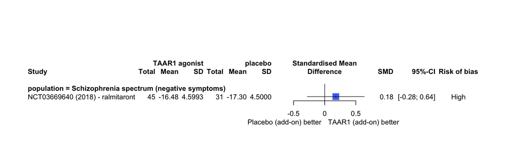

**Figure 79** Forest plot for positive symptoms (measured with PANSS postivie Marder factor) for the comparison of adjunctive TAAR1 agonist vs. placebo to antipsychotic treatment at 3-13 weeks (primary timepoint). The overall risk of bias of the studies for this outcome is presented. SMD:Standardized mean difference, 95%CI: 95% confidence intervals, SD: Standard deviation.

#### Timepoint 3: *> 13 weeks*

No usable data available from RCT.

### 6.3.3 Negative symptoms

#### Timepoint 1: *1 day - 2 weeks*

No usable data available from RCT.

#### Timepoint 2: *3 weeks - 13 weeks*

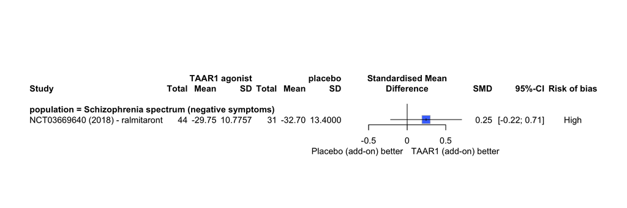

#### Timepoint 3: *> 13 weeks*

No usable data available from RCT.

### 6.3.4 Depressive symptoms

#### Timepoint 1: *1 day - 2 weeks*

No usable data available from RCT.

#### Timepoint 2: *3 weeks - 13 weeks*

No usable data available from RCT.

#### Timepoint 3: *> 13 weeks*

No usable data available from RCT.

### 6.3.5 Cognitive symptoms

#### Timepoint 1: *1 day - 2 weeks*

No usable data available from RCT.

#### Timepoint 2: *3 weeks - 13 weeks*

No usable data available from RCT.

#### Timepoint 3: *> 13 weeks*

No usable data available from RCT.

### 6.3.6 Quality of life

#### Timepoint 1: *1 day - 2 weeks*

No usable data available from RCT.

#### Timepoint 2: *3 weeks - 13 weeks*

No usable data available from RCT.

#### Timepoint 3: *> 13 weeks*

No usable data available from RCT.

### 6.3.7 Functioning

#### Timepoint 1: *1 day - 2 weeks*

No usable data available from RCT.

#### Timepoint 2: *3 weeks - 13 weeks*

No usable data available from RCT.

#### Timepoint 3: *> 13 weeks*

No usable data available from RCT.

### 6.3.8 Response to treatment

#### Timepoint 1: *1 day - 2 weeks*

No usable data available from RCT.

#### Timepoint 2: *3 weeks - 13 weeks*

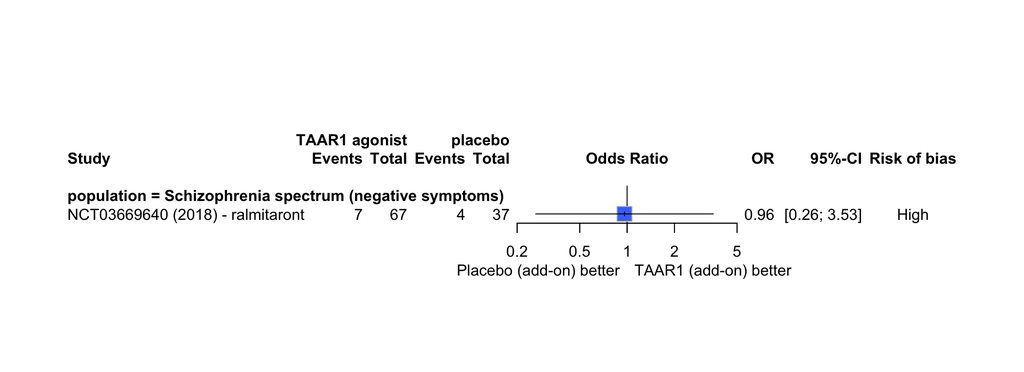

**Figure 81** Forest plot for response (imputed; >50% symptom reduction in PANSS total from baseline) for the comparison of adjunctive TAAR1 agonist vs. placebo to antipsychotic treatment at 3-13 weeks (primary timepoint). The overall risk of bias of the studies for this outcome is presented. OR=Odds ratio, 95%CI: 95% confidence intervals.

#### Timepoint 3: *> 13 weeks*

No usable data available from RCT.

### 6.3.9 Secondary outcome: Relapse

#### Timepoint 1: *1 day - 2 weeks*

No usable data available from RCT.

#### Timepoint 2: *3 weeks - 13 weeks*

There were usable data for one study (Hoffmann-La Roche 2024), which reported 0 events in both groups so that an effect size could not be estimated with the current approach.

#### Timepoint 3: *> 13 weeks*

No usable data available from RCT.

### 6.3.10 Dropouts due to any reason

#### Timepoint 1: *1 day - 2 weeks*

No usable data available from RCT.

#### Timepoint 2: *3 weeks - 13 weeks*

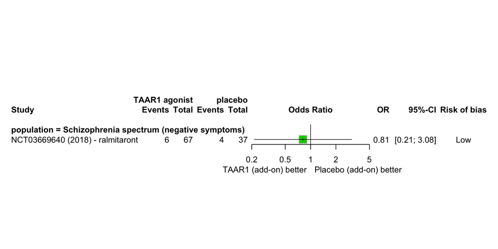

**Figure 82** Forest plot for dropouts due to any reason for the comparison of adjunctive TAAR1 agonist vs. placebo to antipsychotic treatment at 3-13 weeks (primary timepoint). The overall risk of bias of the studies for this outcome is presented. OR=Odds ratio, 95%CI: 95% confidence intervals.

#### Timepoint 3: *> 13 weeks*

No usable data available from RCT.

### 6.3.11 Dropouts due to adverse event

#### Timepoint 1: *1 day - 2 weeks*

No usable data available from RCT.

#### Timepoint 2: *3 weeks - 13 weeks*

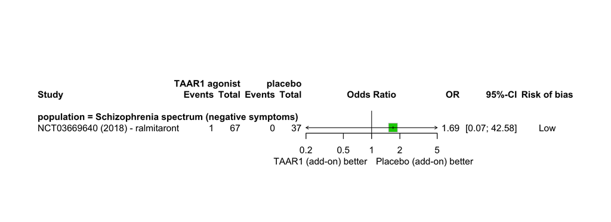

**Figure 83** Forest plot for dropouts due to adverse event for the comparison of adjunctive TAAR1 agonist vs. placebo to antipsychotic treatment at 3-13 weeks (primary timepoint). The overall risk of bias of the studies for this outcome is presented. OR=Odds ratio, 95%CI: 95% confidence intervals.

#### Timepoint 3: *> 13 weeks*

No usable data available from RCT.

### 6.3.12 Serious adverse event

#### Timepoint 1: *1 day - 2 weeks*

No usable data available from RCT.

#### Timepoint 2: *3 weeks - 13 weeks*

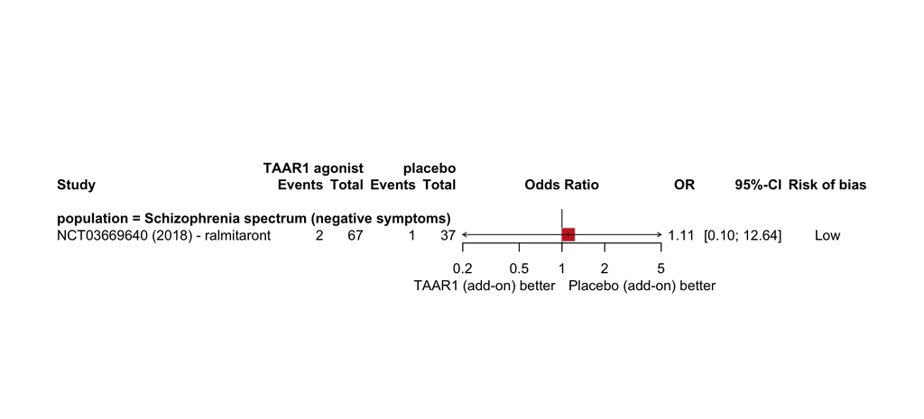

**Figure 84** Forest plot for serious adverse events for the comparison of adjunctive TAAR1 agonist vs. placebo to antipsychotic treatment at 3-13 weeks (primary timepoint). The overall risk of bias of the studies for this outcome is presented. OR=Odds ratio, 95%CI: 95% confidence intervals

#### Timepoint 3: *> 13 weeks*

No usable data available from RCT.

### 6.3.13 Death

#### Timepoint 1: *1 day - 2 weeks*

No usable data available from RCT.

#### Timepoint 2: *3 weeks - 13 weeks*

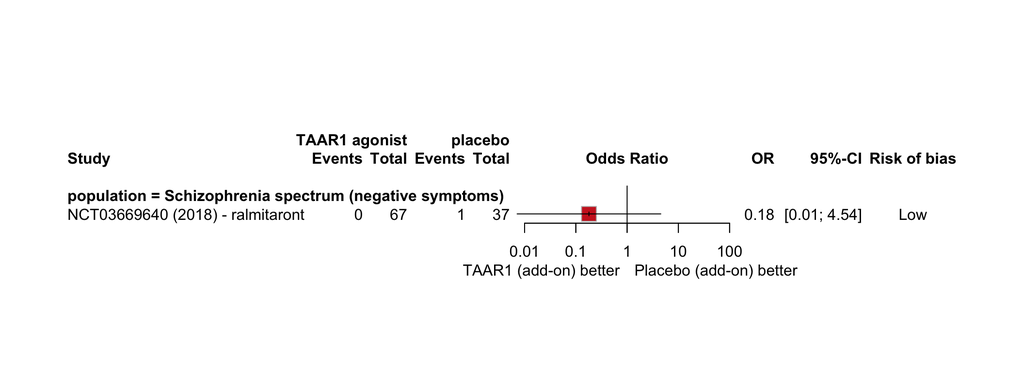

**Figure 85** Forest plot for death for the comparison of adjunctive TAAR1 agonist vs. placebo to antipsychotic treatment at 3-13 weeks (primary timepoint). The overall risk of bias of the studies for this outcome is presented. OR=Odds ratio, 95%CI: 95% confidence intervals.

#### Timepoint 3: *> 13 weeks*

No usable data available from RCT.

### 6.3.14 Any adverse event

#### Timepoint 1: *1 day - 2 weeks*

No usable data available from RCT.

#### Timepoint 2: *3 weeks - 13 weeks*

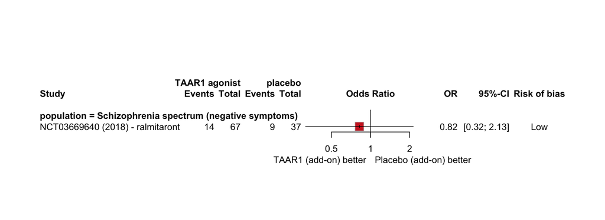

**Figure 86** Forest plot for any adverse event for the comparison of adjunctive TAAR1 agonist vs. placebo to antipsychotic treatment at 3-13 weeks (primary timepoint). The overall risk of bias of the studies for this outcome is presented. OR=Odds ratio, 95%CI: 95% confidence intervals.

#### Timepoint 3: *> 13 weeks*

No usable data available from RCT.